# week05_in_class

## Notes on project 1

- If score is C or less, schedule a meeting with me ASAP
- install spellcheck extension
- when introducing code, before the code cell you need text:
  - briefly describe the code
  - explain the purpose of that code
- before result/plot we need text:
  - what you are going to show
  - why you are showing it
- after results/plot:
  - describe the result
  - analyze the result (why is it important, why the relevant behavior is happening)
- conclusion: should contain a summary of the most important results, and a brief summary of the project topic.
- code needs comments!!!

## Project 2

```python
import matplotlib.pyplot as plt
from matplotlib.patches import Circle
import matplotlib.cm as cm
from scipy.special import zetac
from math import sqrt,pi
import random
```

## From week 4

### Step 0

Given a convergent series (either p-series or geometric)

$p=2$, $\sum_{n=1}^\infty \frac{1}{n^2}$

- find radius, center (0,0) of the black circle. How to find `R`?
- $A=\sum_{n=1}^\infty \frac{1}{n^p}=\zeta(2)=1.6...$
- $R=\sqrt{\frac{A}{\pi}}$

```python
from scipy.special import zetac
```

```python
1+zetac(2) # sum without n=1 term
```

```
1.6449340668482264
```

```python
A=1+zetac(2)
R=(A/pi)**0.5
R
```

```
0.7236012545582677
```

```python
from matplotlib.patches import Circle
```

```python
ax1=plt.subplot(1,1,1)
ax1.add_patch( Circle([0,0],R,fc='k',zorder=1) )
ax1.add_patch( Circle([0.5,0.5],0.1,fc='y',zorder=2) )
ax1.add_patch( Circle([-0.25,-0.25],0.05,fc='c',zorder=2) )
plt.axis('equal')
plt.xlim([-1.1*R,1.1*R])
plt.ylim([-1.1*R,1.1*R])
plt.show()
```

[figure not shown]

### Define a function which will compute all the radii

`gen_radii(p,series,N)`

- `p` = series parameter
- `series` = 'geometric' or 'pseries'
- `N` = how many circle

output

- `R` = radius of big circle
- `rlist` = radii of the N small circles

```python
def myfun(a,b,c):
    blist=[a-c,b-c]
    return a+b,blist
```

```python
myfun(10,3,15)
```

```
(13, [-5, -12])
```

```python
a,alist=myfun(10,3,15)
```

```python
a
```

```
13
```

```python
alist
```

```
[-5, -12]
```

```python
def gen_radii(p,series,N):
    """computes the radius of the big circle R, and the N radii or the small circles (in rlist),
    given a series and the value of p"""

    alist=[]

    if series == 'geometric':
        compute the area of the big circle `S` using the formula for the sum of the geometric series

        find the area of N small circles, using the terms of the geom. series p^n
        (use either list comprehension or for loop)

    elif series == 'pseries':
        S = 1+zetac(p) # sum of conv. p-series

        find the area of N small circles, using the terms of the pseries (1/n)**p
        (use either list comprehension or for loop)
    else:
        return 'Series type non-valid'

    R = sqrt(S/pi) or (S/pi)**0.5 (how we compute the radius)
    compute rlist from alist

    return R,rlist
```

```python
def myfun(a,b):
    return a,[a,b],b
```

```python
myfun(3,2)
```

```
(3, [3, 2], 2)
```

```python
m=myfun(6,7)
print(m)
print(m[0])
print(m[1])
A=m[0]
B=m[1]
C=m[2]
C
```

```
(6, [6, 7], 7)
6
[6, 7]
```

```
7
```

```python
A,mylist,B=myfun(4,5)

print(A)
print(mylist)
print(B)
```

```
4
[4, 5]
5
```

Plotting routine (step 3) should be a function

```python
R = 2
rlist = [0.5,0.25,0.125,0.0625,0.03125]
xlist = [-1,1.5,0,0.9,0.7]
ylist = [1,1.7,0.8,0.9,0.5]

colors=[cm.cool((r**-1)%1) for r in rlist]

ax1=plt.subplot(1,1,1)
ax1.add_patch( Circle([0,0],R,fc='k',zorder=1) )

for k in range(len(xlist)):
    ax1.add_patch( Circle([xlist[k],ylist[k]],rlist[k],fc=colors[k],zorder=2) )

plt.axis('equal')
plt.xlim([-1.1*R,1.1*R])
plt.ylim([-1.1*R,1.1*R])
plt.show()
```

[figure not shown]

Create a function called `gen_centers(R,rlist)` that will create the centers of the small circles s.t. the are

- center of small circles is randomly generated
- small circle is inside the big circle
- small circle is disjoint from any other small circle

outputs:

```python
help(random.random)
```

```
Help on built-in function random:

random(...) method of random.Random instance
    random() -> x in the interval [0, 1).
```

```python
random.random() # random number in [0,1)
```

```
0.1871446155130897
```

`gen_centers` function should generate a center for each small circle with coordinates in [-R,R]

```python
def gen_centers(R,rlist,nmax):

    N=len(rlist)


    xlist=[]
    ylist=[]

    loop k (index) on N centers

        nattempt=0

        while nattempt<nmax:

            x=generate xcoord at random in (-R,R) [random.random() -> in [0,1) -> (-0.5) [-0.5,0.5) -> * 2R [-R,R) ]
            y=generate ycoord at random in (-R,R)

            - How to check if a circle is all inside the black circle
            if sq(x^2 + y^2) > R-r (failure)
                nattempt+=1
                continue

            - check if new circle (x,y,r) is disjoint form all other small circles (xa,ya,ra)
            if isdijoint()==False
                nattempt+=1
                continue
            else:
                break while loop

        if we tried nmax times we shoudl stop the loop on k


        add coordinates to their respective list

    return xlist,ylist

NOTE: you might find less than N centers.
```

```python
pick series,p,N (pick values of p close to 1)

R,rlist=gen_radii(...)
....=gen_centers(R,rlist)

plot
```

```python
colors=[cm.cool((r**-1)%1) for r in rlist]

ax1=plt.subplot(1,1,1)
ax1.add_patch( Circle([0,0],R,fc='k',zorder=1) )

for k in range(len(xlist)):
    ax1.add_patch( Circle([xlist[k],ylist[k]],rlist[k],fc=colors[k],zorder=2) )

plt.axis('equal')
plt.xlim([-1.1*R,1.1*R])
plt.ylim([-1.1*R,1.1*R])
plt.show()
```

```python
import math as m

def isdisjoint(x,y,r,xa,ya,Ra):
    '''This function checks if the circle with center (x,y) and radius r is disjoint
    from all the circles with center (xa[k],ya[k]) and radius Ra[k].
    The function returns True if the circles are disjoint, False otherwise'''
    # x,y,r: (x,y) center coordinates, and radius of circle
    # xa,ya,Ra: (xa,ya) list of center coordinates, and list of Radii of other circles
    disjoint = True
    n = len(Ra)
    for k in range(n):
        d=m.sqrt( (x-xa[k])**2 + (y-ya[k])**2 )
        if d < r+Ra[k]:
            disjoint=False
            break

    return disjoint
```

```python
isdisjoint(goofx,goofy,goofr,xlist,ylist,rlist[])
```

## Thursday

q6 - sample_quiz 4

```python
def myfun(a,b=0):
    return a-b
```

```python
myfun(3,2)
```

```
1
```

```python
myfun(3)
```

```
3
```

```python
mylist=[0,1,2,3,4]
i=3
while len(mylist)>2:
    mylist[i]=mylist[i]*2
    mylist.pop(i-1)
    i-=1
print(mylist)
```

```
[24, 4]
```

```python
mylist.insert(0,99)
```

```python
mylist
```

[output not shown]

```python
help(random.seed)
```

```
Help on method seed in module random:

seed(a=None, version=2) method of random.Random instance
    Initialize internal state from hashable object.

    None or no argument seeds from current time or from an operating
    system specific randomness source if available.

    If *a* is an int, all bits are used.

    For version 2 (the default), all of the bits are used if *a* is a str,
    bytes, or bytearray.  For version 1 (provided for reproducing random
    sequences from older versions of Python), the algorithm for str and
    bytes generates a narrower range of seeds.
```

```python
random.seed(10)
print(random.random())
print(random.random())
```

```
0.5714025946899135
0.4288890546751146
```

```python
random.seed(10)
print(random.random())
print(random.random())
```

```
0.5714025946899135
0.4288890546751146
```

## Numpy

```python
import numpy as np
```

key feature are `arrays`

```python
mylist=[1,2,3]
myarray=np.array(mylist)
```

```python
print(mylist)
print(myarray)
```

```
[1, 2, 3]
[1 2 3]
```

```python
type(mylist)
```

```
list
```

```python
type(myarray)
```

```
numpy.ndarray
```

want to produce the list containing the cubes of the elements of `mylist`

```python
mylist
```

```
[1, 2, 3]
```

```python
cubes=[]
for k in mylist:
    cubes.append(k**3)
```

```python
cubes
```

```
[1, 8, 27]
```

```python
array_cubes=myarray**3
```

```python
array_cubes
```

```
array([ 1,  8, 27])
```

```python
mylist**3
```

```
---------------------------------------------------------------------------
TypeError                                 Traceback (most recent call last)
<ipython-input-51-4c0f24fa10b0> in <module>
----> 1 mylist**3

TypeError: unsupported operand type(s) for ** or pow(): 'list' and 'int'
```

```python
myarray+1
```

```
array([2, 3, 4])
```

```python
print(myarray//2)
```

```
[0 1 1]
```

element by element operations (if size is matching)

```python
a=np.array([1,2,3])
b=np.array([3,4,7])
```

```python
print(a+b)
```

```
[ 4  6 10]
```

```python
a*b
```

```
array([ 3,  8, 21])
```

```python
from math import sin
```

```python
sin(a)
```

```
---------------------------------------------------------------------------
TypeError                                 Traceback (most recent call last)
<ipython-input-59-d7a1e1a26ccc> in <module>
----> 1 sin(a)

TypeError: only size-1 arrays can be converted to Python scalars
```

```python
np.sin(a)
```

```
array([0.84147098, 0.90929743, 0.14112001])
```

```python
z=[1,2,3]
y=z
```

```python
z[2]=99

print(z,y)
```

```
[1, 2, 99] [1, 2, 99]
```

```python
z=[1,2,3]
y=z[:]
z[2]=99

print(z,y)
```

```
[1, 2, 99] [1, 2, 3]
```

```python
z=[1,2,3]
y=z.copy()
z[2]=99

print(z,y)
```

```
[1, 2, 99] [1, 2, 3]
```

```python
a=np.array([1,2,3])
b=a[:] # does not produce a copy of an array
# it produces a 'view' of the array
c=a.copy() # c=np.copy(a)

a[0]=120

print(a,b,c)
```

```
[120   2   3] [120   2   3] [1 2 3]
```

You can slice arrays the same way as for lists

```python
a
```

```
array([120,   2,   3])
```

```python
a=np.array([1,2,3,4,5,6,7,8,9])
```

```python
a[8]
```

```
9
```

```python
a[:4]
```

```
array([1, 2, 3, 4])
```

```python
a[::2]
```

```
array([1, 3, 5, 7, 9])
```

Numpy arrays:

- can be sliced likes lists
- to make a copy we must use .copy()
- their dimension cannot be changed after they are created
- each element of the array must have the same type
- support vectorial operations

## How to create them

`np.array()`

```python
np.array(range(9)) # something not to do
```

```
array([0, 1, 2, 3, 4, 5, 6, 7, 8])
```

```python
np.array([1,2,3,4])
```

```
array([1, 2, 3, 4])
```

`np.ones`, `np.zeros`, `np.empty`

```python
np.ones(4) # an array of size 4 with all ones
```

```
array([1., 1., 1., 1.])
```

```python
np.zeros(7)# an array of size 7 with all zeros
```

```
array([0., 0., 0., 0., 0., 0., 0.])
```

```python
np.empty(8) # an array of size 8 with random entries
# used to create an empty array that you will fill later
```

```
array([0.00000000e+000, 0.00000000e+000, 2.31297541e-312, 2.41907520e-312,
       2.33419537e-312, 2.35541533e-312, 8.48798317e-313, 6.91940388e-310])
```

```python
help(np.empty)
```

[output not shown]

**Ex** create array with 11 entries that are all 8

```python
8*np.ones(11)
```

```
array([8., 8., 8., 8., 8., 8., 8., 8., 8., 8., 8.])
```

`np.arange`

```python
np.arange(3)
```

```
array([0, 1, 2])
```

```python
np.arange(-1,4)
```

```
array([-1,  0,  1,  2,  3])
```

```python
np.arange(1,11,3)
```

```
array([ 1,  4,  7, 10])
```

```python
np.arange(0,1.6,0.5)
```

```
array([0. , 0.5, 1. , 1.5])
```

`np.linspace`

```python
np.linspace(0,1,11) # array from 0 to 1 with 11 points (1 steps)
                    # equally spaced
```

```
array([0. , 0.1, 0.2, 0.3, 0.4, 0.5, 0.6, 0.7, 0.8, 0.9, 1. ])
```

```python
len(np.linspace(0,1,11))
```

```
11
```

**ex** plot the circle of radius 2 center (0,0) using the parametric equation

$$t \in [0,2\pi), \quad x=2\cos(t),\quad y=2\sin(t)$$

using 1001 points

```python
np.pi
```

```
3.141592653589793
```

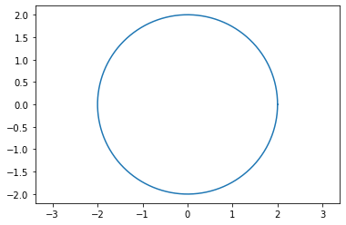

```python
t=np.linspace(0,2*np.pi,1001)
x=2*np.cos(t)
y=2*np.sin(t)

plt.plot(x,y)
plt.axis('equal');
```

```python
from time import time
```

```python
startt=time()
x=np.arange(1,10**8)
y=np.log(x)
endt=time()
print(endt-startt)
```

```
0.45751166343688965
```

```python
import math as m
```

```python
startt=time()
x=list(range(1,10**8))
y=[]
for k in x:
    y.append(m.log(k))
endt=time()
print(endt-startt)
```

```
16.47340416908264
```